# Assignment 4 - Heart rate, respiration and interpersonal coordination

Sigrid Agersnap, Anders Hjulmand and Gustav Helms

November 25, 2020

# Assignment 4 - Heart rate, respiration and interpersonal coordination

Physiological data (here heart rate [variability], and respiration) are increasingly popular. Historically treated as pernicious noise to be regressed out of neuro-imaging data, there is now increasing research on how these signals tell us something important about cognition and beyond being just a signal of cognitive processes also impact them in interesting ways. Advanced sport science, and the quantified self movement (closely followed by marketing and communication) have hailed continuous physiological tracking as a powerful way to access and modify attitudes, habits, and performance. Further, as team coordination (in the military, in decision processes and organizational contexts) is more and more in focus, research has attempted to measure how interpersonal coordination between physiological systems might tell us something important about e.g. emotional and cognitive coordination. See references in the reading list for more on this.

In this assignment, you will learn to: - pre-process physiological data (and grow further your mad R skills) - model the continuous interdependence between two signals (using a multilevel model as proxy for a dynamical system approach) - conservatively assess the presence of coordination between to signals in a controlled context

This assignment has two parts. The first part familiarizes you with heart rate, and respiration data and their preprocessing. The second part explores how to analyze interpersonal coordination of these signals.

These are the questions you need to be able to answer at the end of the assignment (aka that you need to submit as part of the portfolio)

1. How do you preprocess heart rate and respiration data? Describe the process. If any data needs to be excluded, list the excluded data and motivate the exclusion.
2. Do you observe interpersonal coordination in heart rate and respiration? Describe your control baseline, the method used to quantify coordination, and the statistical models used to infer whether coordination was higher than in the baseline. Report the results of the models.
3. Do you observe differences in coordination between conditions? Report the models and results.
4. Is respiration coordination a likely driver of heart rate coordination? Describe how you would test for it. Bonus points if you actually run the tests and report methods and results.

N.B. N.B. The data are collected by students from previous years (Study 1 - 4). Note that synchronous and turn-taking are the same across all four studies, but the third condition is different: in the first year it was self-paced joint reading; in the second to fourth years it was the tv-series conversation.

## Let’s get started

### Exploring physiological signals

The data files can be found here: https://www.dropbox.com/sh/bvvk7t3fvsplh9o/AADM6q4WrtXKvSwH5aAO1umta?dl=0

- Choose one pair (one pair, three conditions, three files)
- Load the logs
- Produce a plot of the participants’ respiration signal and a different one of the participants’ HR signal. N.B: remember the slides: artifacts, downsampling, scaling. N.B. The gridExtra::grid.arrange() function allows you to display the plots side by side. E.g. grid.arrange(plot1, plot2, plot3, ncol=3). There are also smarter packages, like cowplot and ggpubr.
- Can you eye-ball which condition if any displays more physiological coordination?

### First we read one data file and identify the procedure

- Load the file
- correctly identify all columns
- plot the data
- deal with the artifacts
- downsample the data
- Add a column for study, group, trial and condition

```r
# Load the libraries # ANDERS
pacman::p_load(tidyverse, groupdata2, gridExtra, lmerTest, reshape2, tidymodels)
```

```r
################################### SINGLE FILE - SIGRID ########################################

# Load the file
df_single <- read_csv("Study1_G1_T1_Synchronous.csv")
```

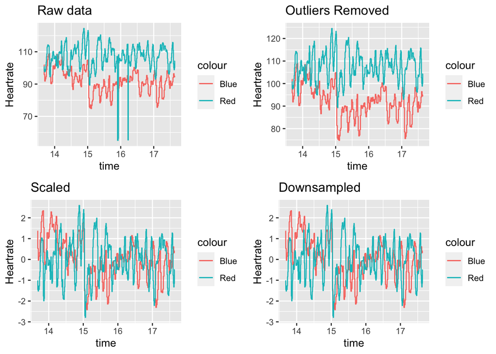

```r
# Plot
plot_single_raw <- ggplot(df_single) +
  geom_path(aes(time, HR1, color = "Blue")) +
  geom_path(aes(time, HR2, color = "Red")) +
  labs(x = "time", y = "Heartrate") +
  ggtitle("Raw data")


## Remove outliers

### Tip, check the function below. This is the function explained in the video lecture
removeOuts <- function(ts,threshold){
  ts[ts > (mean(ts,na.rm=T) +
             (threshold*sd(ts,na.rm=T))) |
       ts < (mean(ts,na.rm=T) -
             (threshold*sd(ts,na.rm=T)))] = mean(ts,na.rm=T)
  return(ts)
}
threshold=2.5 # Default value at 2.5 sds from the mean. But you can increase it, if you want.

df_single <- df_single %>%
  mutate(
    HR1 = removeOuts(HR1, threshold),
    HR2 = removeOuts(HR2, threshold),
    Resp1 = removeOuts(Resp1, threshold),
    Resp2 = removeOuts(Resp2, threshold),
  )

# Plot raw data against those with the artifacts removed
plot_single_outlier <- ggplot(df_single) +
  geom_path(aes(time, HR1, color = "Blue")) +
  geom_path(aes(time, HR2, color = "Red")) +
  labs(x = "time", y = "Heartrate") +
  ggtitle("Outliers Removed")

## Scale
### Tip: if scale() gives some issues, try the one below
z_scale <- function(column){
  column_c <- (column - mean(column)) / sd(column)
}

df_single <- df_single %>%
  mutate(
    HR1 = z_scale(HR1),
    HR2 = z_scale(HR2),
    Resp1 = z_scale(Resp1),
    Resp2 = z_scale(Resp2)
  )

# Plot again to check how scaled data look like
plot_single_scale <- ggplot(df_single) +
  geom_path(aes(time, HR1, color = "Blue")) +
  geom_path(aes(time, HR2, color = "Red")) +
  labs(x = "time", y = "Heartrate") +
  ggtitle("Scaled")


## Downsample
### You can use the code below. It is almost the same as the one in the video lecture.
df_single <- df_single %>%
  group(n = 100, method = 'greedy') %>%
  dplyr::summarise(
   time = mean(time,na.rm=T),
    HR1 = mean(HR1,na.rm=T),
    HR2 = mean(HR2,na.rm=T),
    Resp1 = mean(Resp1,na.rm=T),
    Resp2 = mean(Resp2,na.rm=T))
#    rowname = rowname[1]) #the index we use to put them back together

## Plot the downsampled data. You can use the code from the slides
plot_single_downs <- ggplot(df_single) +
  geom_path(aes(time, HR1, color = "Blue")) +
  geom_path(aes(time, HR2, color = "Red")) +
  labs(x = "time", y = "Heartrate") +
  ggtitle("Downsampled")


grid.arrange(plot_single_raw, plot_single_outlier, plot_single_scale, plot_single_downs)
```

## Now we are ready to go to load and pre-process all files

Go through all the files (with a function passed onto map_df), check which files should be excluded, if any, and save the pre-processed time-series. This procedure is similar to what you have done in portfolio 3. You may use the code you wrote for that assignment and adjust it to this one.

A couple of tips: - looping will be too slow for these files (remember you have ~200 000 rows in each file!). Making a function and using Map/Map_df is your salvation. - you may want your first step after loading a file to be downsampling, so that you don’t work with enormous amount of data - each study restarts the group numbering, so you should make sure to change that (e.g. 100 * Study + Group) - you need to make sure all the data are meaningful or something has to be removed. Plotting is your friend. E.g. “Study1_G1_T1_Synchronous” has one bad respiration signal. We could replace it with NAs

```r
###################### FIXING STUDY 4 COLUMN NAMES - GUSTAV ###########################

#### the coloumn "time" is named "Time" in study 4. This is a problem for pre_processing function. So we have moved all csv-files in study 4 to a new folder called data_4. This for-loop iterates over all the study4-files, creates a new coloum called "time", and overwrites the old file.
#Dont run this chunk if your folder-structure doesnt allow it.

list_study4 = list.files(path = "data_4/", pattern = ".csv")

for (filename in list_study4){
  path_name <- paste0("data_4/",filename)
  data = read_csv(path_name)

  data <- data %>%
    mutate(
      time = min
    )
  write_csv(data, path_name)
}
```

```r
############################ FUNCTION FOR PREPROCESSING - ANDERS ############################

data_preprocess <- function(filename, threshold = 2.5){

  # Reading data
  path_name <- paste0("data_fixed/",filename)
  data <- read_csv(path_name)

  # Downsampling
  data = data %>%
  group(n = 100, method = 'greedy') %>%
  dplyr::summarise(
    time = mean(time,na.rm=T),
    HR1 = mean(HR1,na.rm=T),
    HR2 = mean(HR2,na.rm=T),
    Resp1 = mean(Resp1,na.rm=T),
    Resp2 = mean(Resp2,na.rm=T),
    ECG1 = mean(ECG1,na.rm = T),
    ECG2 = mean(ECG2,na.rm = T))

  # Preprocessing
  data <- data %>%
  mutate(
    # Extracting ID collumns
    Study = str_extract_all(filename, "\\d")[[1]][1],
    Pair = str_extract(filename, "G\\d{1,2}"),
    Pair = str_extract(Pair, "\\d{1,2}"),
    Trial = str_extract(filename, "T\\d"),
    Trial = str_extract(Trial, "\\d"),
    Condition = str_sub(filename, 14, -5),
    Condition = str_replace(Condition, "_", ""),
    ID = paste0(Study, Pair),
    fileID = paste0(Study, Pair, Trial),
    Time = time,

    # Removing outliers and scaling
    Resp1 = z_scale(removeOuts(Resp1, threshold)),
    Resp2 = z_scale(removeOuts(Resp1, threshold)),
    ECG1 = z_scale(removeOuts(ECG1, threshold)),
    ECG2 = z_scale(removeOuts(ECG2, threshold)),
    HR1 = z_scale(removeOuts(HR1, threshold)),
    HR2 = z_scale(removeOuts(HR2, threshold))

  ) %>%
    select(
      c(ID, fileID, Study, Pair, Trial, Condition, time, HR1:ECG2))

  return(data)
}
```

```r
############################### PURE MAGIC M8 - SIGRID ###################################

data <- list.files(path = "data_fixed/", pattern = ".csv") %>%
  map_df(data_preprocess)
```

```r
################ REMOVING NA's AND FIXING TIME VARIABLE TO ARBITRARY - GUSTAV #####################
data <- data %>%
  filter(
    !is.na(time),
    !is.na(HR1),
    !is.na(HR2),
    !is.na(Resp1),
    !is.na(Resp2)
  ) %>%
  group_by(fileID) %>%
  mutate(
    time = seq(n())
  )
```

```r
#write to csv
write_csv(data, "FINAL_DATA.csv")
```

```r
#loading data
df <- read_csv("FINAL_DATA.csv")
```

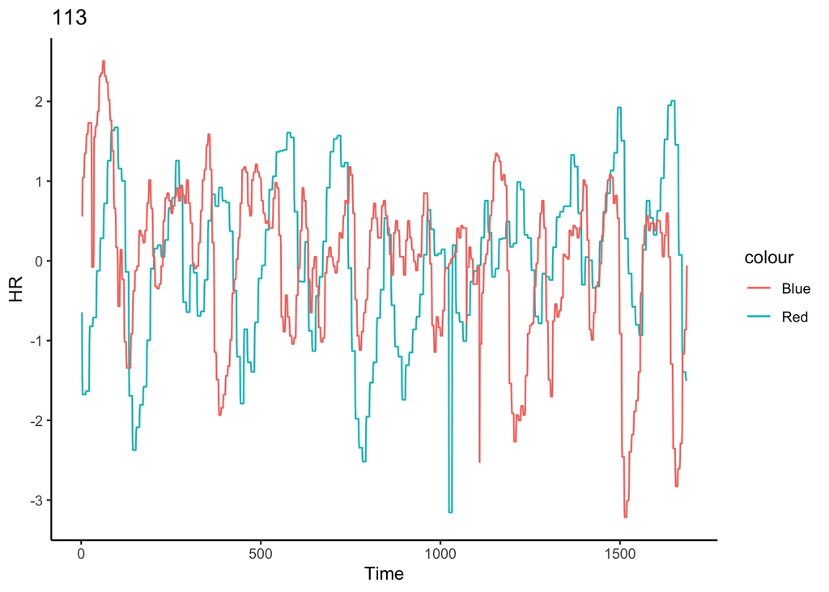

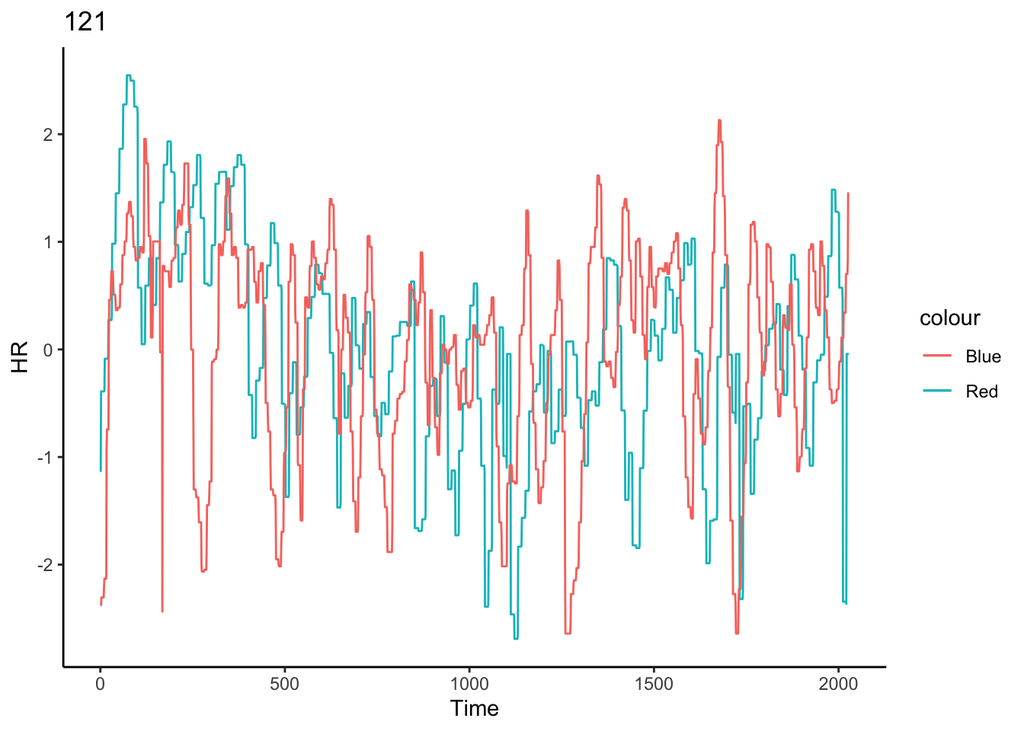

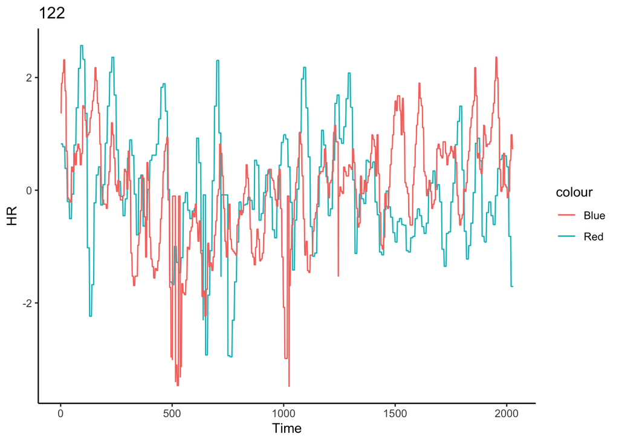

```r
########################## SEARCHING FOR ARTEFACTS - ANDERS #####################################

# Now we need to make sure all the data are meaningful or something has to be removed
# E.g. "Study1_G1_T1_Synchronous" has one bad respiration signal. We could replace it with NAs

# We create two functions for plotting HR and Resp for an individual file. By running the functions on each file we can investigate the files for artefacts and remove files with bad data.

# Function for HR
plotting_hr <- function(file){
  df %>%
    filter(fileID == file) %>%
    ggplot()+
      geom_path(aes(time, HR1, color = "Red"))+
      geom_path(aes(time, HR2, color = "Blue"))+
      labs(x = "Time", y = "HR", title = file)+
      theme_classic()
}

# Function for Resp
plotting_resp <- function(file){
  df %>%
    filter(fileID == file) %>%
    ggplot()+
      geom_path(aes(time, Resp1, color = "Red"))+
      geom_path(aes(time, Resp2, color = "Blue"))+
      labs(x = "Time", y = "Resp", title = file)+
      theme_classic()
}

# Listing files
files <- unique(df$fileID)

# Heart Rate - Only first three files
for(f in files[1:3]){
  plot <- plotting_hr(f)
  print(plot)
}
```

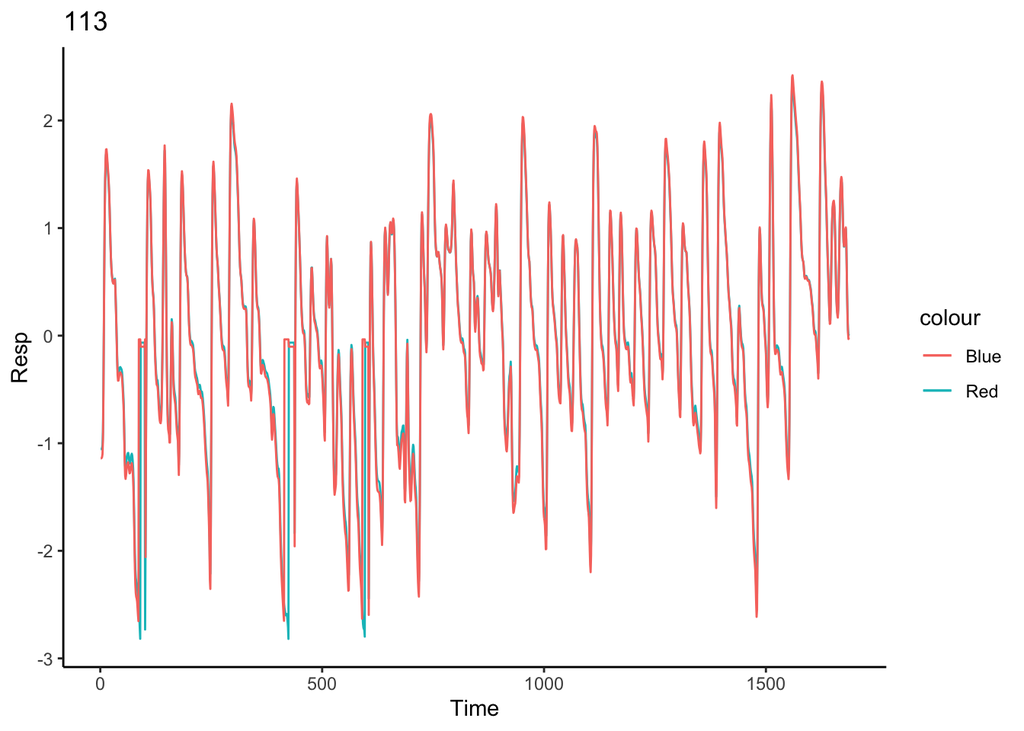

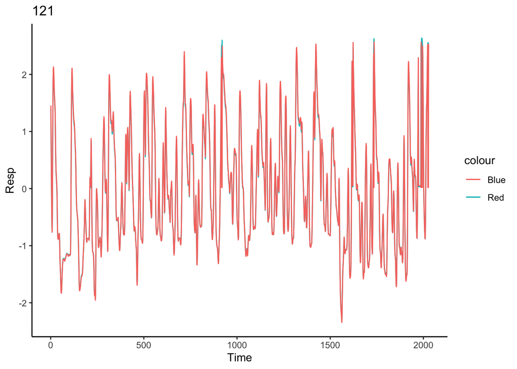

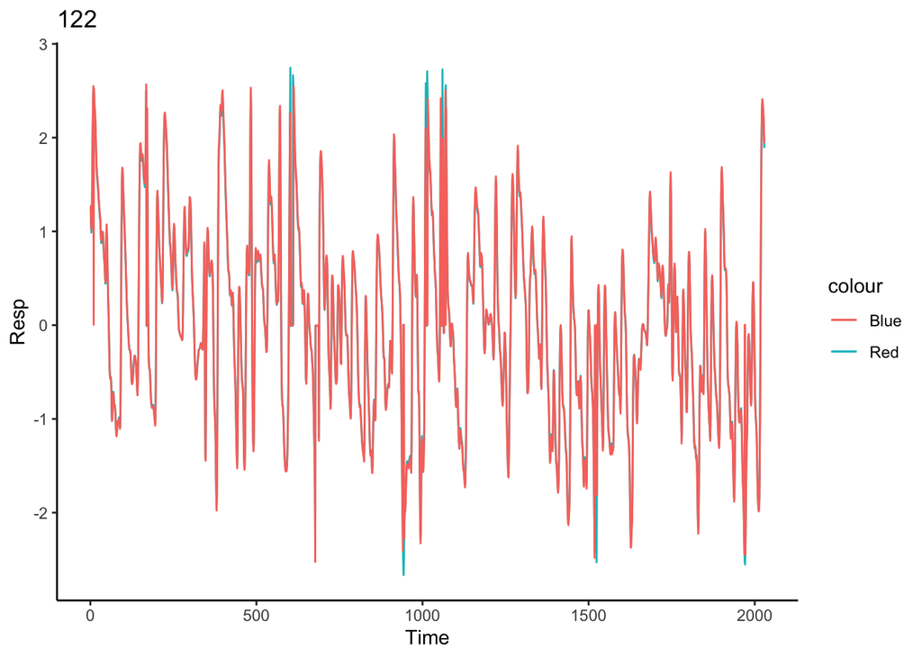

```r
# Respiration - Only first three files
for(f in files[1:3]){
  plot <- plotting_resp(f)
  print(plot)
}
```

```r
#After having looked through all the plots we have decided to exclude the following files (see rapport for more information) - GUYSTAV
files_to_remove <- c(433, 461, 132, 313, 435,251, 252, 253, 261, 262, 263, 392, 281, 282, 283, 111, 112, 435, 392, 414)

data_clean <- df %>%
  filter( !(fileID %in% files_to_remove))
```

```r
############################ PREPROCESSING DONE #######################################

#write to csv
write_csv(data_clean, "FINAL_DATA.csv")
```

## Now we need to run some analysis

Let’s start with a multilevel model that accounts for - stability (how each signal is autocorrelated) - interpersonal dependence (each signal is dependent from the previous state of the other signal)

The data needs to be further prepared, so we can analyze both participants in the same model. We need to turn the data into a long format: - a column indicating own hr and one own respiration - a column indicating other hr and one other respiration - a column indicating change in hr from previous round and one in respiration

We can then run an analysis where change is a function of one’s previous state (stability, see slides), and the other’s previous state (coupling). Make sure to: - set up the most interesting contrasts: how do these parameters vary by condition? which condition should be baseline? - set up the right random effects. - N.B. the model will be slow. Make sure it works on a subset of the data first!

Bonus question: what if we include an additional layer? Is my heart rate just adjusting to yours, or also to how much you are adjusting to mine? - to start answering this we can add a column indicating the previous change in hr in the other and one in respiration - we can then build on the previous models by also adding the previous change in the other

```r
################## LOADING PREPROCESSED DATA ######################
df <- read_csv("FINAL_DATA.csv")
```

```r
####################### REFORMATING DATA TO FIT ANALYSIS - SIGRID ########################

df <- df %>%

  # Transforming the data into a long format
  melt(id.vars = c("ID", "fileID", "Study", "Pair", "Trial", "Condition", "time")) %>%
  mutate(
    # Making an ifelse statement that sorts participant 1 and 2.
    Participant = ifelse(variable == "HR1" | variable == "Resp1" ,
                         paste0("1",as.character(ID)),
                         paste0("2", as.character(ID))),
    Participant = as.numeric(Participant)
  ) %>%

  # Making the data wide format again
  spread(variable, value) %>%

  #Arranging the data by fileID and time
  arrange(fileID, time) %>%

  # Creating the different parameters
  mutate(
    #The original measurements
    par_no = str_extract(as.character(Participant), "\\d"),
    HR_self = ifelse(par_no == 1, HR1, HR2),
    HR_other = ifelse(par_no == 2, lag(HR_self), lead(HR_self)),
    Resp_self = ifelse(par_no == 1, Resp1, Resp2),
    Resp_other = ifelse(par_no == 2, lag(Resp_self), lead(Resp_self)),

    #The previous values
    HR_previous_self = lag(HR_self, n = 2),
    HR_previous_other = lag(HR_other, n = 2),
    Resp_previous_self = lag(Resp_self, n = 2),
    Resp_previous_other = lag(Resp_other, n = 2),

    #The next values
    HR_lead_self = lead(HR_self, n = 2),
    HR_lead_other = lead(HR_other, n = 2),
    Resp_lead_self = lead(Resp_self, n = 2),
    Resp_lead_other = lead(Resp_other, n = 2),

    #The change parameters
    HR_change_self = HR_lead_self - HR_self,
    HR_change_other = HR_lead_other - HR_other,
    Resp_change_self = Resp_lead_self - Resp_self,
    Resp_change_other = Resp_lead_other - Resp_other,

    Condition = as.factor(Condition)
  ) %>%
  # Deselecting irelevant collumns
  select(
    !(HR1:Resp2)
  )
```

```r
######################## BASELINE - GUSTAV ############################
levels(df$Condition)
```

```
## [1] "Conversation"   "MovementCoop"   "MovementGuided" "SelfPaced"
## [5] "Synchronous"    "TurnTaking"
```

```r
#conversation is our baseline
```

```r
##################### SIMPLE MODEL AND PLOT FOR 1 PARTICIPANT - HR - SIGRID ######################
#simple models
HR_model1 <- lm(HR_change_self ~0+ (HR_self + (HR_other-HR_self)) : Condition,
                subset(df, Study=="4" & Participant == 142))
summary(HR_model1)
```

```
##
## Call:
## lm(formula = HR_change_self ~ 0 + (HR_self + (HR_other - HR_self)):Condition,
##     data = subset(df, Study == "4" & Participant == 142))
##
## Residuals:
##     Min      1Q  Median      3Q     Max
## -4.2828 -0.0281  0.0002  0.0301  4.7063
##
## Coefficients:
##                                   Estimate Std. Error t value Pr(>|t|)
## HR_self:ConditionConversation    -0.027065   0.006282  -4.308 1.67e-05 ***
## HR_self:ConditionMovementCoop    -0.033848   0.008177  -4.139 3.52e-05 ***
## HR_self:ConditionMovementGuided  -0.051915   0.007961  -6.521 7.45e-11 ***
## HR_self:ConditionSynchronous     -0.028967   0.005822  -4.976 6.64e-07 ***
## HR_self:ConditionTurnTaking      -0.029888   0.005906  -5.060 4.28e-07 ***
## HR_other:ConditionConversation    0.012926   0.006282   2.057   0.0397 *
## HR_other:ConditionMovementCoop    0.005926   0.008177   0.725   0.4687
## HR_other:ConditionMovementGuided -0.002993   0.007961  -0.376   0.7069
## HR_other:ConditionSynchronous     0.009623   0.005822   1.653   0.0984 .
## HR_other:ConditionTurnTaking     -0.002339   0.005906  -0.396   0.6921
## ---
## Signif. codes:  0 '***' 0.001 '**' 0.01 '*' 0.05 '.' 0.1 ' ' 1
##
## Residual standard error: 0.2441 on 7378 degrees of freedom
## Multiple R-squared:  0.01779,    Adjusted R-squared:  0.01646
## F-statistic: 13.37 on 10 and 7378 DF,  p-value: < 2.2e-16
```

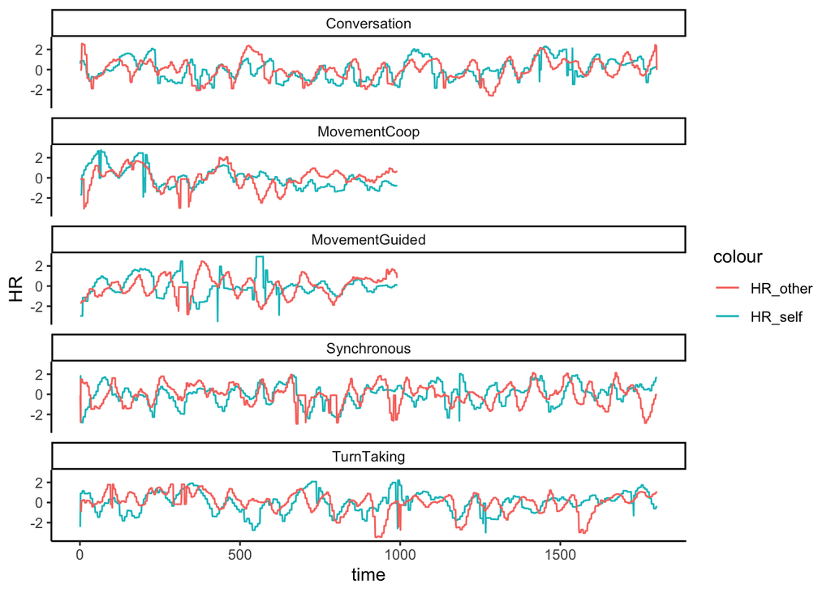

```r
# Plotting one participant for all conditions
df %>%
  subset(Study=="4") %>%
  group_by(Participant, Condition) %>%
  mutate(time=seq(n())) %>%
  subset(Participant == 142) %>%
  ggplot() + geom_line(aes(time, HR_self, color="HR_self")) + geom_line(aes(time, HR_other, color="HR_other")) + facet_wrap(Condition ~ ., ncol =1 )+ labs(y = "HR")+ theme_classic()
```

```r
################ SIMPLE MODEL AND PLOT FOR 1 PARTICIPANT - Resp - ANDERS #####################
#simple models
Resp_model1 <- lm(Resp_change_self ~0+ (Resp_self + (Resp_other-Resp_self)) : Condition,
                subset(df, Study=="4" & Participant == 142))
summary(Resp_model1)
```

```
##
## Call:
## lm(formula = Resp_change_self ~ 0 + (Resp_self + (Resp_other -
##     Resp_self)):Condition, data = subset(df, Study == "4" & Participant ==
##     142))
##
## Residuals:
##      Min       1Q   Median       3Q      Max
## -2.91768 -0.07675 -0.00999  0.05812  2.63265
##
## Coefficients:
##                                    Estimate Std. Error t value Pr(>|t|)
## Resp_self:ConditionConversation    -0.27421    0.02001 -13.705  < 2e-16
## Resp_self:ConditionMovementCoop    -0.07697    0.01955  -3.937 8.32e-05
## Resp_self:ConditionMovementGuided  -0.06531    0.01559  -4.190 2.82e-05
## Resp_self:ConditionSynchronous     -0.44431    0.02259 -19.667  < 2e-16
## Resp_self:ConditionTurnTaking      -0.18853    0.01437 -13.119  < 2e-16
## Resp_other:ConditionConversation    0.25573    0.02001  12.781  < 2e-16
## Resp_other:ConditionMovementCoop    0.05709    0.01955   2.920  0.00351
## Resp_other:ConditionMovementGuided  0.04571    0.01559   2.932  0.00338
## Resp_other:ConditionSynchronous     0.41564    0.02259  18.398  < 2e-16
## Resp_other:ConditionTurnTaking      0.16147    0.01437  11.236  < 2e-16
##
## Resp_self:ConditionConversation    ***
## Resp_self:ConditionMovementCoop    ***
## Resp_self:ConditionMovementGuided  ***
## Resp_self:ConditionSynchronous     ***
## Resp_self:ConditionTurnTaking      ***
## Resp_other:ConditionConversation   ***
## Resp_other:ConditionMovementCoop   **
## Resp_other:ConditionMovementGuided **
## Resp_other:ConditionSynchronous    ***
## Resp_other:ConditionTurnTaking     ***
## ---
## Signif. codes:  0 '***' 0.001 '**' 0.01 '*' 0.05 '.' 0.1 ' ' 1
##
## Residual standard error: 0.2504 on 7378 degrees of freedom
## Multiple R-squared:  0.09711,    Adjusted R-squared:  0.09589
## F-statistic: 79.36 on 10 and 7378 DF,  p-value: < 2.2e-16
```

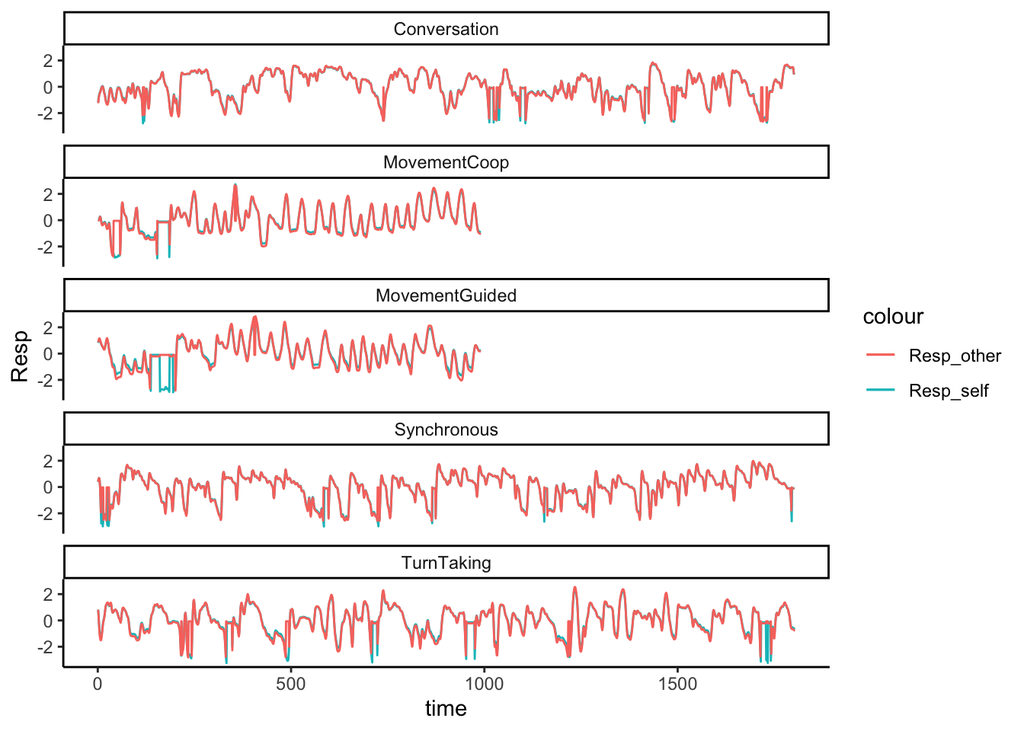

```r
# Plotting one participant for all conditions
df %>%
  subset(Study=="4") %>%
  group_by(Participant, Condition) %>%
  mutate(time=seq(n())) %>%
  subset(Participant == 142) %>%
  ggplot() + geom_line(aes(time, Resp_self, color="Resp_self")) + geom_line(aes(time, Resp_other, color="Resp_other")) + facet_wrap(Condition ~ ., ncol =1 )+ labs(y = "Resp")+ theme_classic()
```

```r
########################### MAKING THE FIRST MODELS - HR ######################## - ANDERS

# Model change as a function of own and other previous state

# Model including only interaction effects with HR
m1 <- lmerTest::lmer(HR_change_self ~ 0 + (HR_self + (HR_other - HR_self)):Condition
                     + (0+Condition|Participant) + (0+Condition|Pair) + (0+Condition|Study),
                     df, REML = F,
                     control = lmerControl(optimizer = "nloptwrap", calc.derivs = F))
summary(m1)

# Model including both interactions and fixed effects with HR
m1_INTER <- lmerTest::lmer(HR_change_self ~ 0 + (HR_self + (HR_other - HR_self))*Condition
                     + (0+Condition|Participant) + (0+Condition|Pair) + (0+Condition|Study),
                     df, REML = F,
                     control = lmerControl(optimizer = "nloptwrap", calc.derivs = F))
summary(m1_INTER)

# We have excluded the intercept since we are only interested in change. We will only be using interaction effects from here on since we are only interested in the change in a given condition. Thus all of our following models's interaction effects will be specified with a ":" instead of "*"

########################### MAKING THE FIRST MODEL - RESP ########################

# Model including only interaction effects with RESP - Very significant
m2 <- lmerTest::lmer(Resp_change_self ~ 0 + (Resp_self + (Resp_other - Resp_self)):Condition
                     + (0+Condition|Participant) + (0+Condition|Pair) + (0+Condition|Study),
                     df, REML = F,
                     control = lmerControl(optimizer = "nloptwrap", calc.derivs = F))
summary(m2)
```

[output not shown]

## Now we need to create control baselines.

First shuffled controls, then surrogate pairs.

### Creating controls: shuffled controls

Shuffled controls break the temporal dependencies of time-series by shuffling the value within one time-series. This ensures the “coordination” observed is not due to the actual values in the series and not their sequence. Tip: sample() is your friend, but make sure to shuffle things within participant/condition and not throughout the whole dataset

```r
####################### CREATING SHUFFLED CONTROLS - SIGRID ##############################

# Creating the type column in the original dataset
df$Type <-  "Real"

# Making a new dataset where all predictor variables are shuffled
df_shuffled <- df %>%
  # Making sure that the data for each participant for each condition is separately sampled.
  group_by(Participant, Condition) %>%

  mutate(
  HR_self = sample(HR_self),
  HR_other = sample(HR_self),
  Resp_self = sample(HR_self),
  Resp_other = sample(HR_self),

  #The previous
  HR_previous_self = sample(HR_previous_self),
  HR_previous_other = sample(HR_previous_other),
  Resp_previous_self = sample(Resp_previous_self),
  Resp_previous_other = sample(Resp_previous_other),

  # The next
  HR_lead_self = sample(HR_lead_self),
  HR_lead_other = sample(HR_lead_other),
  Resp_lead_self = sample(Resp_lead_self),
  Resp_lead_other = sample(Resp_lead_other),

  # The change
  HR_change_self = sample(HR_change_self),
  HR_change_other = sample(HR_change_other),
  Resp_change_self = sample(Resp_change_self),
  Resp_change_other = sample(Resp_change_other),

  Type = "Shuffled"
  )

# Concatenating the two dataframes with each others
df_shuffled <- rbind(as.data.frame(df_shuffled),as.data.frame(df))
```

```r
################### CREATING MODELS WITH SHUFFLED CONTROLS AS BASELINE ################## - SIGRID

# HR
m1_shuffled <- lmerTest::lmer(HR_change_self ~ 0 + (HR_self + (HR_other - HR_self)):Condition:Type
                     + (0+Condition|Participant) + (0+Condition|Pair) + (0+Condition|Study),
                     df_shuffled, REML = F,
                     control = lmerControl(optimizer = "nloptwrap", calc.derivs = F))
summary(m1_shuffled)

# Resp
m2_shuffled <- lmerTest::lmer(Resp_change_self ~ 0 + (Resp_self + (Resp_other - Resp_self)):Condition:Type
                     + (0+Condition|Participant) + (0+Condition|Pair) + (0+Condition|Study),
                     df_shuffled, REML = F,
                     control = lmerControl(optimizer = "nloptwrap", calc.derivs = F))
summary(m2_shuffled)
```

### TRICKY! Creating controls: surrogate pair controls

- Per each real pair, identify at least one surrogate pair (matching one of the participants, with somebody doing the same task, but in a different pair)

```r
################################ CREATING SURROGATE PAIRS - GUSTAV ##############################
# PS: THIS RECIPE IS HOMEMADE
# PPS: HOMEMADE IS ALWAYS THE BEST


# Making sure that the surrogate pairs created are replicated
set.seed(125)

# Making a new dataframe with surrogate pair id's
hep <- df %>%
  #Grouping by study and condition
  group_by(Study,Condition) %>%

  #Getting unique participant IDs
  summarise(participant = unique(Participant)) %>%

  #Extracting info on whether they are par1 or par2 in a pair
  mutate(par.no = str_extract(as.character(participant), "\\d") ) %>%

  #Making seperate collumns for par1 and par2
  pivot_wider(names_from = par.no, values_from = participant) %>%

  # Renaming the columns
  rename(
    par1 = 3,
    par2 = 4
  ) %>%

  # Unpacking the lists from the pivot_wider function
  unnest(cols = c("par1","par2")) %>%

  # Randomizing par2 within study and condition to make the new surrogate pairs
  mutate(par2 = sample(par2)) %>%

  # Ungrouping in order to make unique surrogatepair names
  ungroup() %>%

  # Making the new surrogate pair numbers
  mutate(Surrogate_ID = seq.int(1,78)) %>%

  # Making the data long format
  melt(id.vars = c("Study","Condition","Surrogate_ID")) %>%

  # Making the unique variable to merge by
  mutate(
    par_cond = as.factor(paste0(as.character(value),Condition))
  ) %>%

  # Selecting the relevant columns
  select(par_cond, Surrogate_ID)
# Because of the random shuffling of the surrogate pairs, some participants are randomly assigned to their original partners.
bad_surrogate_pairs <- c(8,9,12,16,17,19,30,31,37,70)

# Making the unique id variable to merge by in the original dataframe
df <- df %>%
  mutate(par_cond = as.factor(paste0(as.character(Participant),Condition)))


######################### MERGING AND FILTERING OUT BAD SURROGATE PAIRS #####################
# Making a new dataframe where the Pair column is replaced with the surrogate ID's
df_surrogate <- merge(df, hep) %>%
  # Reformating the dataframe to make it compatible with the original data
  mutate(
    Pair = Surrogate_ID,

    # Creating a type column to use in the model
    Type = "Surrogate") %>%

  select(!("Surrogate_ID")) %>%

  # Filtering out bad surrogate pairs
  filter(
    !(Pair %in% bad_surrogate_pairs)
  )  %>%

###################### REMAKING THE "OTHER" COLUMNS ACCORDING TO SURROGATE PAIRS #############
  # Ordering by pair and time
  arrange(Pair, time) %>%

  group_by(Pair) %>%

  # Some fileIDs have more datapoints than others. Removing these redundant datapoints, to make sure that each surrogate pair has equal amount of data.
  mutate(par_no = ifelse(par_no == lead(par_no), 0, par_no)) %>%
  filter(par_no != 0) %>%

  # Making the new "other" columns according to the new pairs.
  mutate(
    HR_other = ifelse(par_no == 2, lag(HR_self), lead(HR_self)),
    Resp_other = ifelse(par_no == 2, lag(Resp_self), lead(Resp_self)),
    HR_previous_other = lag(HR_other, n = 2),
    Resp_previous_other = lag(Resp_other, n = 2),
    HR_lead_other = lead(HR_other, n = 2),
    Resp_previous_other = lead(Resp_other, n = 2),
    HR_change_other = HR_lead_other - HR_other,
    Resp_change_other = Resp_lead_other - Resp_other
  ) %>%
  select(c(ID:Type,par_cond))

# Binding the surrogate dataframe to the original data
df_surrogate <- rbind(as.data.frame(df), as.data.frame(df_surrogate))
```

```r
################### CREATING MODELS WITH SURROGATE PAIRS AS BASELINE ####################### - GUSTAV

# Create models as in chunks above, but adding an interaction with the Real vs. Surrogate variable (exclude shuffled ones for simplicity)

# HR
m1_surrogate <- lmerTest::lmer(HR_change_self ~ 0 + (HR_self + (HR_other - HR_self)):Condition:Type
                     + (0+Condition|Participant) + (0+Condition|Pair)+(0+Condition|Study),
                     df_surrogate, REML = F,
                     control = lmerControl(optimizer = "nloptwrap", calc.derivs = F))
summary(m1_surrogate)

# Resp
m2_surrogate <- lmerTest::lmer(Resp_change_self ~ 0 + (Resp_self + (Resp_other - Resp_self)):Condition:Type
                     + (0+Condition|Participant) + (0+Condition|Pair) + (0+Condition|Study),
                     df_surrogate, REML = F,
                     control = lmerControl(optimizer = "nloptwrap", calc.derivs = F))
summary(m2_surrogate)
```

### Effects of respiration coordination on heart rate coordination

- describe how you would test those.
- Optional: run the models and report them